# Лабораторная работа №2

Кибербезопасность предприятия. Сценарий №5

Боровиков Даниил

Хрусталев Влад

Гисматуллин Артём

Чесноков Артёмий

Коннова Татьяна

Нефедова Наталья

Уткина Алина

Бансимба Клодели

Российский университет дружбы народов, Москва, Россия

## Задачи

ЗАЩИТА НАУЧНО-ТЕХНИЧЕСКОЙ ИНФОРМАЦИИ ПРЕДПРИЯТИЯ

Средство обнаружения вторжений – программно-аппаратный комплекс для обнаружения вторжений в информационные системы ViPNet IDS NS.

Автоматическое выявление инцидентов на основе интеллектуального анализа событий информационной безопасности – программно-аппаратный комплекс ViPNet TIAS.

ViPNet EPP применяется для защиты отдельных компонентов информационной инфраструктуры организаций – персональных компьютеров пользователей и корпоративных серверов.

## Действия нарушителя

1. Внутренний нарушитель подбирает пароль на файловый сервер и меняет существующий на сервере файл другим файлом с backdoor (дефектом алгоритма).
2. Пользователь Dev-1 загружает и запускает файл с backdoor.
3. Внутренний нарушитель получает контроль над компьютером пользователя Dev-1 и загружает скрипт для похищения учетных данных из браузера. Запускает данный скрипт и получает логин и пароль к Redmine.

## Действия нарушителя

4. Внутренний нарушитель проводит атаку stored XSS для включения на Redmine сервере REST API. Вредоносный код записывается на Wikiстраницу проекта Dev1. Получив доступ к консоли администратора, внутренний нарушитель создает нового пользователя Redmine с правами администратора.
5. Внутренний нарушитель ожидает, когда администратор просмотрит страницу с внедренным вредоносным кодом.
6. Внутренний нарушитель проводит Blind SQL-инъекцию, получает доступ к данным конфиденциального проекта.

# Процесс выполнения лабораторной работы

## Последствие Dev backdoor

[figure not shown]

Файл svchosting.exe в папке Downloads

## Последствие Dev backdoor

[figure not shown]

Задание “Evil task” в планировщике задач

## Последствие Dev backdoor

[figure not shown]

Настройки задания с путем к вредоносному файлу

## XSS-код

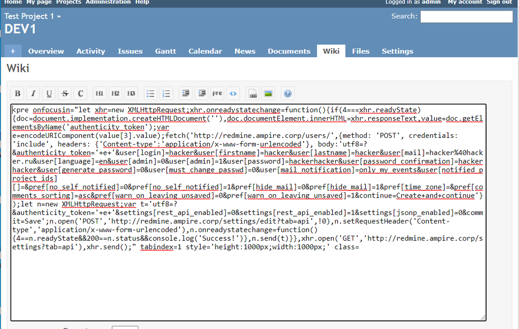

Вредоносный XSS-код на Wiki-странице

## redcloth3.rb

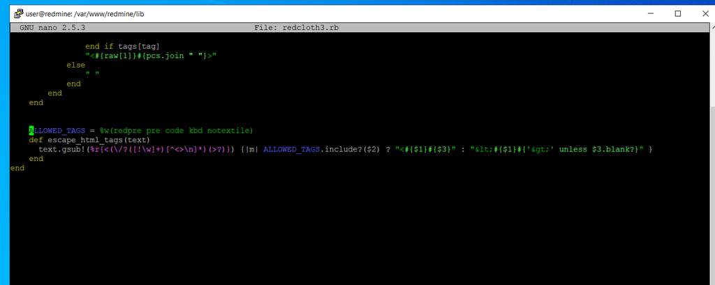

Исходный код файла redcloth3.rb

## redcloth3.rb

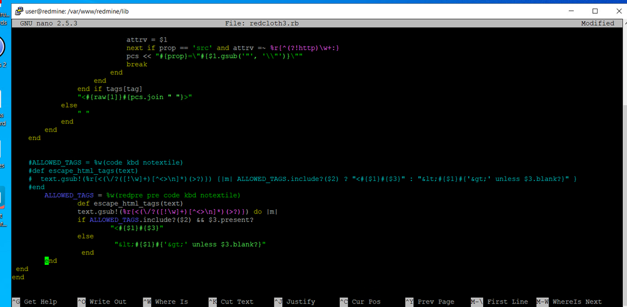

Исправленная версия файла redcloth3.rb

## Перезапуск службы

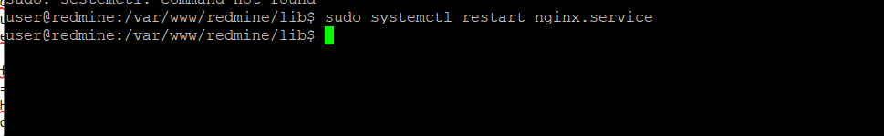

Перезапуск службы nginx

## Список пользователей

[figure not shown]

Список пользователей Redmine с пользователем “hacker”

## Удаление пользователя

[figure not shown]

Подтверждение удаления пользователя

## Изучение логов

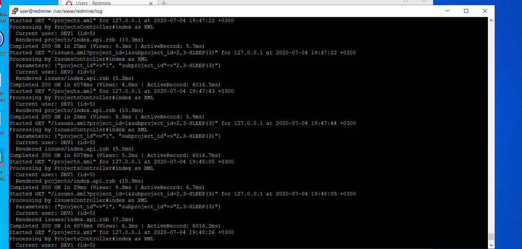

Логи Redmine с SQL-инъекцией

## query.rb

[figure not shown]

Исправление в файле query.rb

## Завершение работы

[figure not shown]

Главная страница

## Завершение работы

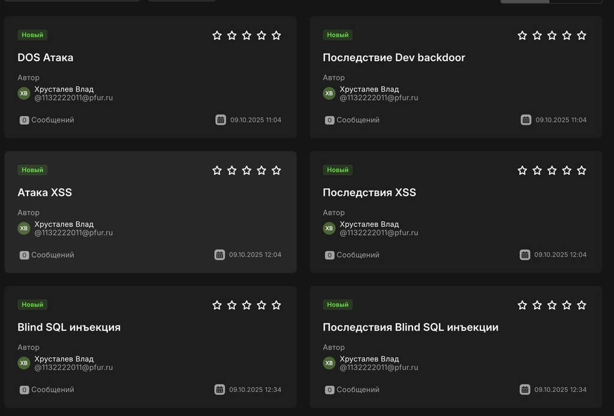

Карточки инцидентов и последствий

## Выводы

В рамках учебно-практического занятия на базе программного комплекса обучения методам обнаружения, анализа и устранения последствий компьютерных атак «Ampire» мы выполнили сценарий №5 «Защита научно-технической информации предприятия». Внутренний нарушитель, используя слабые пароли и уязвимости в веб-приложении Redmine, осуществил комплексную атаку с целью получения доступа к конфиденциальной информации. Нарушитель применил техники внедрения backdoor, эксплуатации XSS-уязвимости и слепой SQL-инъекции для создания привилегированного пользователя и несанкционированного доступа к данным. Уровень сложности сценария — 8 (из 10). Мы успешно выявили уязвимости, проанализировали последствия атаки, устранили их и отработали методы детектирования с использованием инструментов ViPNet IDS NS, ViPNet TIAS и Security Onion, а также освоили методики исправления исходного кода приложений для устранения уязвимостей.